# MATH 4773 Project 2

Ben Gochanour

03 November, 2019

Abstract

In this study, I seek to determine the factors influencing the number of clerical hours worked at a department store. These factors include the day of the week in addition to output statistics (such as number of checks cashed or returns processed). This might be useful for a store manager who wishes to predict labor costs based on expected demand, for example. To perform this analysis, I utilize Multiple Linear Regression (MLR). I check all assumptions of this analysis and produce a final model that is both parsimonious and predictive.

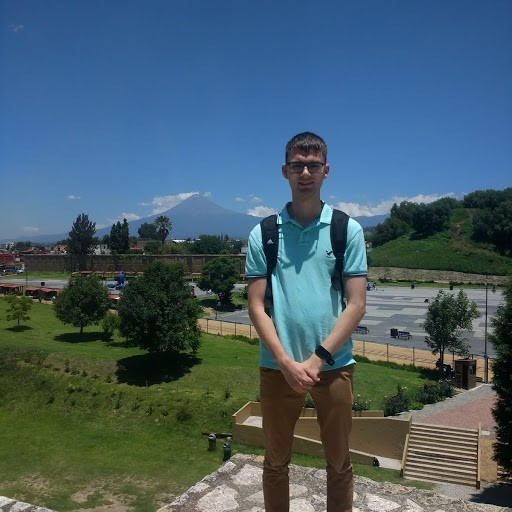

Ben Gochanour

# 1 Introduction

Labor expenses represent one of the highest costs for retailers (Dunham (1993)), especially in stores that have little automation of clerical work. In this study, I seek to determine if day of week and various output factors are predictive of total clerical hours worked per day at a department store (which will ultimately influence the overall labor cost of each day). To do this, I will build an MLR model and conduct hypothesis testing and interval estimation, with the hope of extracting useful information that will help store management to make the best possible decisions. Importantly, there will be a heavy focus on the statistical methodology that underlies this study. Below, I have placed a video that walks you through the study. However, you may also keep reading to see the full analysis and output.

[video not shown]

## 1.1 What are the variables?

First, we would like to examine the data and understand the variables we will use to predict clerical hours worked.

```r
library(readxl)
library(ggiraphExtra)
library(GGally)
library(s20x)
data=read_excel("CLERICAL.xls")
data=data[,-1] # remove obs num col
names(data)=c("day","hours","mail","gifts","charge","returns","checks","misc",'tickets')
data['day']=as.factor(data$day)
head(data)
```

| day | hours | mail | gifts | charge | returns | checks | misc | tickets |
| --- | --- | --- | --- | --- | --- | --- | --- | --- |
| M | 128.5 | 7781 | 100 | 886 | 235 | 644 | 56 | 737 |
| T | 113.6 | 7004 | 110 | 962 | 388 | 589 | 57 | 1029 |
| W | 146.6 | 7267 | 61 | 1342 | 398 | 1081 | 59 | 830 |
| Th | 124.3 | 2129 | 102 | 1153 | 457 | 891 | 57 | 1468 |
| F | 100.4 | 4878 | 45 | 803 | 577 | 537 | 49 | 335 |
| S | 119.2 | 3999 | 144 | 1127 | 345 | 563 | 64 | 918 |

```r
summary(data)
```

```
##  day        hours            mail           gifts            charge
##  F :8   Min.   : 86.6   Min.   : 1832   Min.   : 14.00   Min.   : 389.0
##  M :9   1st Qu.:107.6   1st Qu.: 4338   1st Qu.: 69.75   1st Qu.: 603.2
##  S :8   Median :117.2   Median : 5542   Median : 90.50   Median : 780.0
##  T :9   Mean   :117.4   Mean   : 5586   Mean   : 90.98   Mean   : 782.3
##  Th:9   3rd Qu.:129.2   3rd Qu.: 6996   3rd Qu.:115.00   3rd Qu.: 924.2
##  W :9   Max.   :150.4   Max.   :11777   Max.   :174.00   Max.   :1419.0
##     returns          checks            misc          tickets
##  Min.   : 84.0   Min.   : 334.0   Min.   :30.00   Min.   : 126.0
##  1st Qu.:128.5   1st Qu.: 460.2   1st Qu.:49.00   1st Qu.: 481.2
##  Median :177.0   Median : 545.5   Median :57.00   Median : 722.5
##  Mean   :211.9   Mean   : 593.9   Mean   :58.27   Mean   : 753.8
##  3rd Qu.:235.8   3rd Qu.: 712.8   3rd Qu.:69.25   3rd Qu.: 958.2
##  Max.   :577.0   Max.   :1081.0   Max.   :86.00   Max.   :1721.0
```

Above, we see a summary and a printout of the data (after brief pre-processing). The full description for each variable is given below:

- day: day of week
- hours: clerical hours worked (in one day)
- gifts: Number of gift cards sold
- charge: Number of store charge accounts transacted
- returns: Number of change order transactions or returns processed
- checks: Number of checks cashed
- misc,tickets: variable def not provided in book

## 1.2 Plot data

Now, we would like to visually inspect the data before further describing it and building models. The `ggpairs` function is excellent for this purpose because it allows us to see all pairwise combinations of variables as well as plots of the distributions of each variable individually.

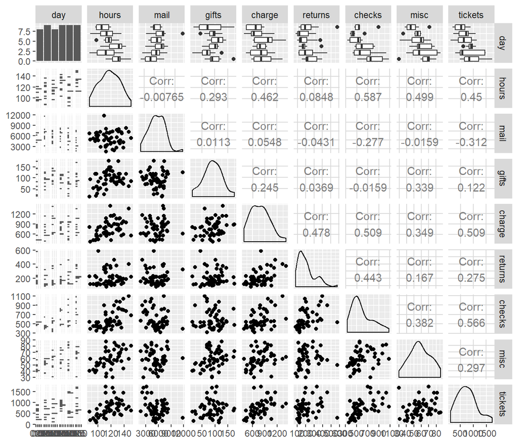

```r
ggpairs(data)
```

I would also like to take a closer look at potential correlations between variables because this can create problems when model building. To do this, there is a nice function called `ggcorr` that will plot a correlation heatmap of the data. We have not used this method in MATH 4773 yet, although I have used it extensively in my personal work because it is a simple way to view all correlations in one place.

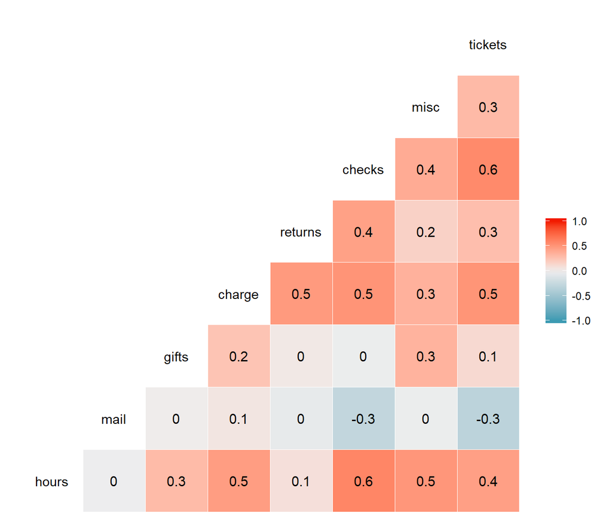

```r
ggcorr(data,label=TRUE)
```

Here, we see that most variables aren’t too highly correlated, although hours and checks and checks and tickets exhibit fairly high correlations of about .6.

## 1.3 Data Background

The data were collected at a department store over the course of 52 days. The textbook does not provide much additonal information on the data collection process, but given what we’ve learned in the last chapter of MATH 4773, I assume that these 52 days were randomly selected from a larger subset (instead of being 52 consecutive days). This would help insure independence and representativeness of our results.

The book also does not state why the data was gathered, but it was likely gathered to help store management make decisions about staffing allocation based on historical data. I am interested in this data because I have worked several retail jobs and I appreicate the challenge it is to accurately predict customer demand and allocate the workforce accordingly. More importantly, however, I am interested in demonstrating how MLR can be used to solve a prediction problem that includes both categorical and quantitative variables.

# 2 Theory needed to carry out MLR

## 2.1 Multiple Linear Regression

Our MLR model is $Y=β_0+β_1x_1+...+β_kx_k+ϵ$, or in matrix form
$$Y=X\beta+\epsilon$$
where Y is an nx1 response vector, X is the design matrix, the betas are the paramaters we are trying to estimate, and $\epsilon$ is our error term.

Then we can estimate the betas in the following way $\hat{\beta}=(X'X)^{−1}X'Y$. This assumes that $(X'X)^{-1}$ has an inverse, which it may not if we have high multicollinearity in our design matrix. Put in linear algebra terms, this happens when $Xa=0$ and $a\ne0$.

It’s easiest to see the derivation of this information from a picture:

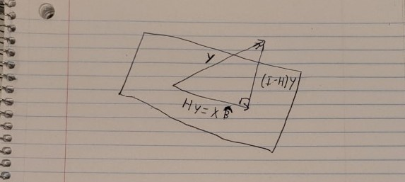

Model picture

Given this picture, we can see that it must be that $HY=X\hat{\beta}$. From this, we can derive H, and also solve for the betas.

$$\begin{equation}
HY=X\hat{\beta}\\
=X(X'X)^{-1}X'Y\\
so\, H=\boxed{X(X'X)^{-1}X'}
\end{equation}$$
Note that all of this relies on some crucial properties of the H (sometimes called the hat matrix), which are outlined below.

1. $H$ is symmetric

$$[X(X^{'}X)^{-1}X^{'}]^{-1}\\
=X[X(X^{'}X)^{-1}]^{'}\\
=X[(X^{'}X)^{-1}]^{'}X^{'}
=X(X^{'}X)^{-1}X{'}=H$$
$$Therefore$$
$$H^{'}=H$$

2. $(I-H)$ is symmetric

$$(I-H)^{'}=I^{'}-H^{'}=I-H$$
$$Therefore$$
$$(I-H)^{'}=(I-H)$$

3. $H$ is idempotent

$$H^2=X(X^{'}X)^{-1}X^{'}*X(X^{'}X)^{-1}X^{'}$$
$$= X(X^{'}X)^{-1}(X^{'}*X)(X^{'}X)^{-1}X^{'}$$
$$= XI(X^{'}X)^{-1}X^{'}=X(X^{'}X)^{-1}X^{'}=H$$
$$Therefore$$

$$H^2=H$$

4. $(I-H)$ is idempotent

$$(I-H)^2=(I-H)$$
$$(I-H)^2=(I-H)(I-H)=I-H-H+H^2=I-H-H+H=I-H$$
$$Therefore$$
$$(I-H)^2=(I-H)$$

5. $HX=X$

$$X(X^{'}X)^{-1}X^{'}X\\
=XI=X\\
Therefore\\
HX=X\\$$

## 2.2 Stepwise Regression and AIC

Now that we’ve introduced Multiple Linear regression, I’d like to focus the rest of the theory section on stepwise regression, given that we don’t have the time to fully cover all of its theory in class. Additionally, I will discuss some disagreement regarding its usage. There are three types of stepwise regression: backward, forward, and both. However, in each case, one variable is considered in each step (for subtraction or addition). Of course, this is where the name “stepwise” comes from.

Essentially, the model is re-run at each step, and our goal is to iteratively come to the best model. Of course, this process requires a numeric way to decide what the “best” model is. The Akaike information criterion (AIC), is the metric preferred for stepwise regression, as it accounts for the tradeoff between the goodness of fit and the simplicty of the model (therefore it attempts to deal with both overfitting and underfitting). It comes from information theory, and seeks to minimize the amount of information lost from the real data to the representation given by the model. For an additional exploration of the theory, see Bozdogan (1987).

Despite its wide popularity, there is somewhat of a controversy regarding stepwise regression. Several have criticized it for how it ignores the difference among the “interpretive value” of the independent variables, and that expert opinion is better than a simple numerical technique (see Flom (2007), Thompson (1991), and Moore Jr. (1996) for example). Others have a theoretical objection to it as it seems to encourage the scientific trend of searching for significant p-values above all else. However, stepwise regression has been used in numerous studies, and the reason is simple: often we are simply interested in creating the best, most predictive model possible. We aren’t always writing a conceptual scientific paper where it helps to have all variables. Instead, we simply want to model a scenario in the most parsimonous, accurate way. Furthermore, the math behind stepwise regression is sound, most objections are essentially philosophical, not mathematical.

# 3 Model Building

First, I fit a naive first-order model with all the variables.

```r
y.lm=lm(hours~.,data=data)
summary(y.lm)
```

```
##
## Call:
## lm(formula = hours ~ ., data = data)
##
## Residuals:
##      Min       1Q   Median       3Q      Max
## -20.8214  -5.8227  -0.7448   5.2106  23.3213
##
## Coefficients:
##               Estimate Std. Error t value Pr(>|t|)
## (Intercept) 63.1125470  9.8628004   6.399 1.45e-07 ***
## dayM         5.1314729  5.7259400   0.896  0.37566
## dayS         4.9593955  6.4187334   0.773  0.44439
## dayT         8.4328227  5.8573175   1.440  0.15793
## dayTh       -5.3588368  5.7836894  -0.927  0.35986
## dayW         7.1842136  5.9239203   1.213  0.23252
## mail         0.0009590  0.0009692   0.989  0.32856
## gifts        0.0419669  0.0497966   0.843  0.40450
## charge       0.0082003  0.0106567   0.769  0.44623
## returns     -0.0358764  0.0175413  -2.045  0.04762 *
## checks       0.0431797  0.0136077   3.173  0.00294 **
## misc         0.2567141  0.1343253   1.911  0.06336 .
## tickets      0.0029809  0.0057185   0.521  0.60513
## ---
## Signif. codes:  0 '***' 0.001 '**' 0.01 '*' 0.05 '.' 0.1 ' ' 1
##
## Residual standard error: 10.51 on 39 degrees of freedom
## Multiple R-squared:  0.6503, Adjusted R-squared:  0.5427
## F-statistic: 6.044 on 12 and 39 DF,  p-value: 8.01e-06
```

Here, we notice that we have many coefficients, even though we started with very few variables. Why is this? Quite simply, this is because our categorical variable “day” has six levels–it seems the store is closed on Sunday–and therefore it is represented by 5 dummy variables (Friday is our baseline). We immediately notice that this model has a global F stat that yields a p-value of roughly zero, so we say this is an adequate model (the null hypothesis of this test is that $\beta_{1}...\beta_{k}$ are zero). However, we’d like to do better. Can we create a slightly simpler model that still conveys almost as much information as this one? AIC is the perfect measure for this task.

## 3.1 Stepwise Regression

We will use the `step()` function in R to conduct our stepwise regression.

```r
my_step=step(y.lm,trace=0)
summary=summary(my_step)
summary
```

```
##
## Call:
## lm(formula = hours ~ day + charge + returns + checks + misc,
##     data = data)
##
## Residuals:
##     Min      1Q  Median      3Q     Max
## -22.289  -5.513   1.206   5.284  23.198
##
## Coefficients:
##              Estimate Std. Error t value Pr(>|t|)
## (Intercept) 69.732773   7.958592   8.762 4.97e-11 ***
## dayM         6.113829   5.459740   1.120  0.26916
## dayS         4.349090   6.248289   0.696  0.49023
## dayT         9.669874   5.479102   1.765  0.08486 .
## dayTh       -6.407061   5.385278  -1.190  0.24083
## dayW         7.262757   5.705454   1.273  0.21004
## charge       0.013625   0.009278   1.469  0.14941
## returns     -0.036040   0.017247  -2.090  0.04274 *
## checks       0.039099   0.012368   3.161  0.00291 **
## misc         0.306376   0.121133   2.529  0.01527 *
## ---
## Signif. codes:  0 '***' 0.001 '**' 0.01 '*' 0.05 '.' 0.1 ' ' 1
##
## Residual standard error: 10.34 on 42 degrees of freedom
## Multiple R-squared:  0.6354, Adjusted R-squared:  0.5572
## F-statistic: 8.131 on 9 and 42 DF,  p-value: 7.341e-07
```

Above, we see the resulting model. We notice that we have retained all of the day of week dummy variables, in addition to charge, returns, checks, and misc. Mail, gifts, and tickets have dropped out. In addition, we notice the very high global F stat and low p-value. Clearly, our model is statistically adequate.

## 3.2 Adjusted $R^2$

```r
summary$adj.r.squared
```

```
## [1] 0.5572118
```

$$R_{adj}^2 = 0.5572118$$
Our adjusted R-Squared is about .5572, meaning that about 55.72% of the variation in hours worked can be explained by the variable’s linear relationship with our predictive variables.

# 4 Model Assumptions

Next, we’d like to check to make sure that our data/model satisfy all appropriate assumptions for MLR.

The following statement provides a nice summary of many of these assumptions:

$$\epsilon_i \sim N(0,\sigma^2)$$
First we need to check the normality component. To do this, we will use the `normcheck` function available in `s20x`.

## 4.1 Shapiro-wilk

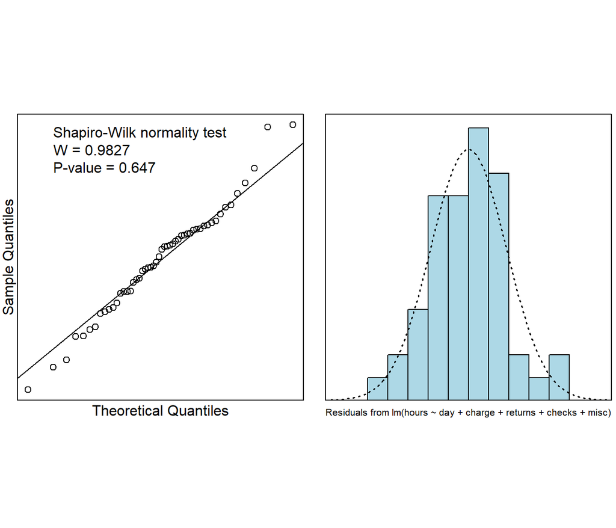

```r
normcheck(my_step,shapiro.wilk=TRUE)
```

The plot on the right appears to show that the errors are roughly normally distributed, although on the left side of the plot, we can see quantitative confirmation of this: the Shapiro-Wilk Normailty test gives us a p-value of .647, so we fail to reject the null hypothesis that the errors are normally distributed.

## 4.2 Constant Variance: Residual vs fitted values

Next we would like to examine the assumption of constant variance. To do this we will examine the plot of residual vs. fitted values.

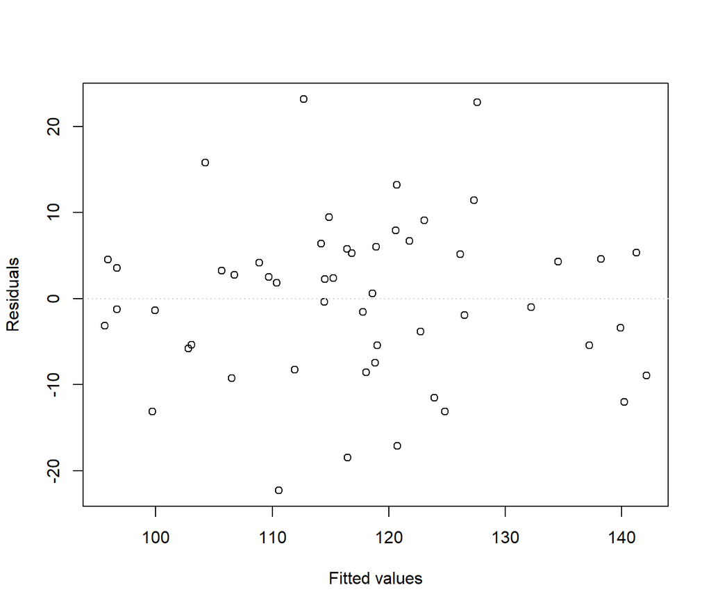

```r
eovcheck(my_step)
```

Here we see the desired result, which is roughly random scatter about zero. We would not like to see a fan shape (or other pattern in the plot), because this would suggest that our constant variance assumption might not be satistified. If this were the case, we would try a log transform of our data. If even this failed to yield significant improvement, we may not be able to proceed with MLR because constant variance is a crucial assumption that the procedure relies on.

## 4.3 Zero mean value of $\epsilon$

```r
mean(summary$residuals)
```

```
## [1] 2.05081e-16
```

This mean is approximately zero, so this assumption is satisfied.

## 4.4 Independence of data

As discussed above, we assume that the data were collected with appropriate randomization and that the hours worked for one observation is not influenced by the hours worked for the other observations.

# 5 Estimation and Further Data Analysis

## 5.1 Point estimate interpretation

Interpretation of all point estimates:

- $\beta_{0}$: On a Friday (base level for day) where essentially no work is done, we would expect to have about 69.73 hrs of clerical work. This interpretation is fairly non-sensical, as it is unlikely that there would be a day with no work to be done.
- $\beta_{1}$: We expect Mondays to have about 6.11 more hours of clerical work than Fridays.
- $\beta_{2}$: We expect Saturdays to have about 4.34 more hours of clerical work than Fridays
- $\beta_{3}$: We expect Tuesdays to have about 9.67 more hours of clerical work than Fridays
- $\beta_{4}$: We expect Thursdays to have about 6.41 fewer hours of clerical work than Fridays
- $\beta_{5}$: We expect Wednesdays to have about 7.26 more hours of clerical work than Fridays
- $\beta_{6}$: For every one unit increase in charge, we expect about a .01 increase in clerical hours worked (assuming all other variables are held constant).
- $\beta_{7}$: For every one unit increase in returns, we expect about a .04 decrease in clerical hours worked (assuming all other variables are held constant).
- $\beta_{8}$: For every one unit increase in checks, we expect about a .04 increase in clerical hours worked (assuming all other variables are held constant).
- $\beta_{9}$: For every one unit increase in misc, we expect about a .31 increase in clerical hours worked (assuming all other variables are held constant).

## 5.2 Confidence intervals

We can use the `confint` function to generate 95% confidence intervals for all beta parameters.

```r
confint(my_step)
```

```
##                    2.5 %       97.5 %
## (Intercept)  53.67168317 85.793862754
## dayM         -4.90437247 17.132030149
## dayS         -8.26046816 16.958649060
## dayT         -1.38740144 20.727149260
## dayTh       -17.27499170  4.460869353
## dayW         -4.25131438 18.776828318
## charge       -0.00509892  0.032349701
## returns      -0.07084548 -0.001234638
## checks        0.01414004  0.064057823
## misc          0.06191995  0.550832824
```

I will not interpret all of these, although I will note that their interpretations have the usual form: "I am 95% confident that for every 1 point increase in `xvar` we expect `yvar` to increase/decrease by between `CIlow` and `CIhigh`.

I will also note that these confidence intervals give us an additional way to observe the statistical significance (or lack thereof) for each beta parameter. We note that any interval containing zero means that the estimate is not significant (at $\alpha = .05$).

## 5.3 Check on outliers using cooks plots

Next, we will examine the data for outliers using the popular metric of Cook’s distance. The often-quoted rule of thumb is that observations with a Cook’s distance greater than $\frac{4}{n}$ (where $n$ is the sample size) should be investigated further.

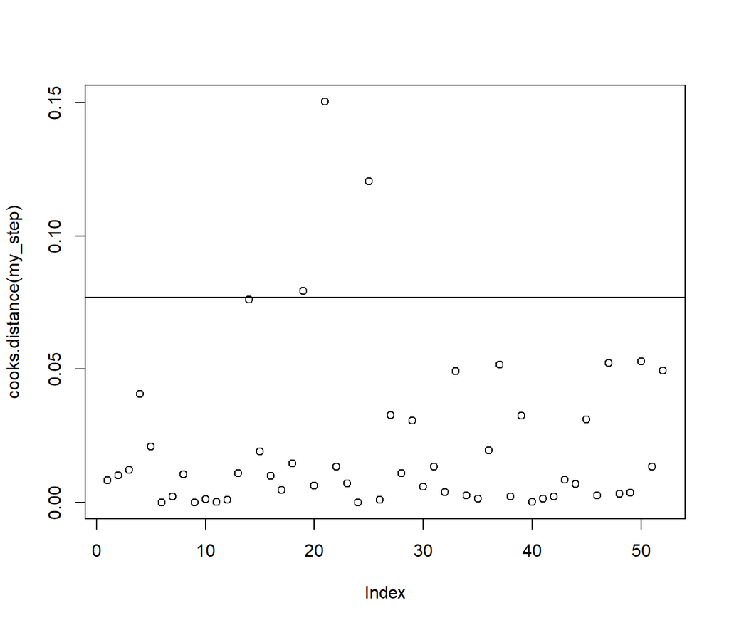

```r
library(car)
plot(cooks.distance(my_step))
abline(h=4/52)
```

## 5.4 Prediction and Model Plots

Here is the section that decision-makers are likely the most interested in: using our model to make predictions. We can use the `predict` function in R to make predictions based on possible **future** observations. We don’t have any data given to predict from, so let’s just predict based on the first observation of our data frame.

```r
val=data.frame(data[1,])
pr=predict(my_step, newdata=val,interval = "prediction")
pr
```

```
##        fit      lwr     upr
## 1 121.7861 99.46114 144.111
```

The interpretation of this is as follows: given future values of the independent variables corresponding to those observed in observation one, we are 95% confident that clerical hours worked will be between 99.461 and 144.111.

Of course, we can use our model to predict clerical hours given other independent variable values from key decison-makers.

## 5.5 Model Plotting

```r
cf=coef(my_step)
cf
```

```
## (Intercept)        dayM        dayS        dayT       dayTh        dayW
## 69.73277296  6.11382884  4.34909045  9.66987391 -6.40706118  7.26275697
##      charge     returns      checks        misc
##  0.01362539 -0.03604006  0.03909893  0.30637639
```

```r
library(rgl)
t <- seq(min(data[,8]), max(data[,8]), length = 100) # from range of data
p <- seq(min(data[,6]), max(data[,6]), length = 100)
xlab=colnames(data[6])
ylab=colnames(data[8])
f <- function(t,p) {cf[1] +t*cf[10] + p*cf[8]}
q <- outer(t,p, f)
bg3d("white")
material3d(col = "green")
rgl.open()
open3d()
```

```
## wgl
##   3
```

```r
persp3d(t, p, q, aspect = c(1, 1, 0.5), col = "lightblue",
              xlab = xlab, ylab = ylab, zlab = "clerical hrs worked")
rglwidget()
```

[interactive chart not shown]

# 6 Conclusion

The answer to our research question is, yes: we can successfully predict clerical hours worked based on the variables provided in the data set. We can go further to specify the most significant predictor variables, most significantly misc, checks, and returns. Because miscellaneous is such a significant predictor variable, it would be prudent for store management to understand the kind of tasks being recorded in this category, and how to reduce this time. Although the data overall is strong, this study suffered from a few limitations. Most significantly, it focus on one department store. Although this may provide specific information for the management of this store, it is not generalizable to all department stores, and certainly not to retail in general. Therefore, a follow-up study might examine more stores with the hope of better understanding the factors predictive of the amount of clerical work.

# References

Bozdogan, H. 1987. *Model Selection and Akaike’s Information Criterion (Aic): The General Theory and Its Analytical Extensions*.

Dunham, DF. 1993. *Food Costs–from Farm to Retail in 1992*.

Flom, PL. 2007. *Stopping Stepwise: Why Stepwise and Similar Selection Methods Are Bad, and What You Should Use*.

Moore Jr., JD. 1996. *Stepwise Methods Are as Bad in Discriminant Analysis as They Are Anywhere Else*.

Thompson, B. 1991. *Stepwise Methods Lead to Bad Interpretations: Better Alternatives.*